# Cross-Border Transmission Regimes: ANOVA and Cluster Analysis

Statistical validation of the transmission-regime taxonomy in the LEEDS MRIO-SFC model

Author

Oriol Vallès Codina

Published

October 2, 2026

[output not shown]

# 1 Introduction

This report statistically validates the five transmission-regime taxonomy used in the LEEDS MRIO-SFC model analysis of circular economy (CE) transition scenarios. The taxonomy classifies 14 CE scenarios into five groups based on their cross-border spillover mechanism:

| Regime | Scenarios | Mechanism |
| --- | --- | --- |
| **Production Leakage** | Sc1, 4, 9 | Secondary sector’s higher import content unintentionally raises RoW intermediate exports |
| **Symmetric Contraction** | Sc3, 6, 7, 8, 11, 12 | Both regions contract proportionally; EU restructuring generates no directional asymmetry |
| **Competitive Displacement** | Sc10 | Secondary metals’ lower A-matrix row-sum frees EU intermediate resources; *only scenario* with true sign reversal (EU↑, RoW↓) |
| **Fossil Import Collapse** | Sc2, 13 | EU fossil import reduction collapses RoW hydrocarbon export revenues; RoW fiscal space deteriorates |
| **Construction Rebound** | Sc5, 14 | Investment channel dominates; CE policy raises fixed investment, reversing ecological sign |

The analysis proceeds in four stages. First, the long-term (t+20) percentage deviation from baseline is computed for each region separately, for an extended set of 34 documented aggregates across all 14 scenarios; the EU−RoW divergence `Z1 − Z2` is formed from these, and the joint `(Z1, Z2)` profile is retained alongside it. Second, a one-way ANOVA tests whether mean divergences differ significantly across regimes for each variable, measuring the effect size with η². Third, hierarchical clustering (Ward’s D2 linkage, Euclidean distance on standardised profiles) is run in both coordinate spaces, and the presence of cluster structure is tested against a permutation null rather than against the gap statistic or a Gaussian mixture model, both of which are unidentified at p/n ≈ 2.4. Fourth, because the number of clusters is not identified at n=14, the paper’s five-regime taxonomy is treated as a hypothesis specified in advance and scored against the data with the adjusted Rand index, block by block, to establish which variables carry the regime signal.

# 2 Data and Variables

Extended variable set used in the analysis

| Label | Full name | Category | Unit | In shock table |
| --- | --- | --- | --- | --- |
| emis | Annual CO2 Emissions | Ecological | 10t CO2 eq. | TRUE |
| land | Land Used | Ecological | ha | TRUE |
| mat | Extraction of Matter | Ecological | 10Mt | TRUE |
| rec | Recycled Matter | Ecological | 10Mt | TRUE |
| wa | Waste | Ecological | 10Mt | TRUE |
| water | Water Used | Ecological | l | TRUE |
| x_mat | Production of Material Goods | Ecological | 10Mt | TRUE |
| c | Total Real Consumption | Households | 10B.EUR | TRUE |
| shp | Profit Share of Disposable Income | Households |  | TRUE |
| shw | Wage Share of Disposable Income | Households |  | TRUE |
| v | Net Household Wealth | Households | 10B.EUR | TRUE |
| b_s | Government Debt | govt.central.bank | 10B EUR | TRUE |
| gdef | Government Deficit | govt.central.bank | 10B.EUR | TRUE |
| id | Real Investment in Fixed Capital | investment | 10B.EUR | TRUE |
| k | Fixed Capital Stock | investment | 10B.EUR | TRUE |
| lf | Corporate Demand for Bank Loans | investment | 10B.EUR | TRUE |
| n | Employment | labor.market | 10M p. | TRUE |
| nf | Female Employment | labor.market | 10M p. | TRUE |
| lh | Household Demand for Personal Loans | portfolio.choices | 10B.EUR | TRUE |
| go | Gross Output | production | 10B.EUR | TRUE |
| va | Value Added | production | 10B.EUR | TRUE |
| co2_cum | CO2 Concentration | Ecological | 10t CO2 eq. | FALSE |
| ineq | Functional Inequality | Households |  | FALSE |
| yd | Disposable Income | Households | 10B.EUR | FALSE |
| ydc | Capitalist Disposable Income | Households | 10B.EUR | FALSE |
| ydw | Worker Disposable Income | Households | 10B.EUR | FALSE |
| imp | Real Final Imports | balance.of.payments | 10B.EUR | FALSE |
| rex | Real Final Exports | balance.of.payments | 10B.EUR | FALSE |
| debt_gdp | Debt to GDP Ratio | govt.central.bank |  | FALSE |
| t | Tax Payments | govt.central.bank | 10B.EUR | FALSE |
| wb | Wage Bill | labor.market | 10B.EUR | FALSE |
| f_f | Corporate Profit | production | 10B.EUR | FALSE |
| fd | Final Demand in Real Terms | production | 10B.EUR | FALSE |
| y | Nominal Output | production | 10B.EUR | FALSE |

# 3 EU−RoW Divergence Heatmap

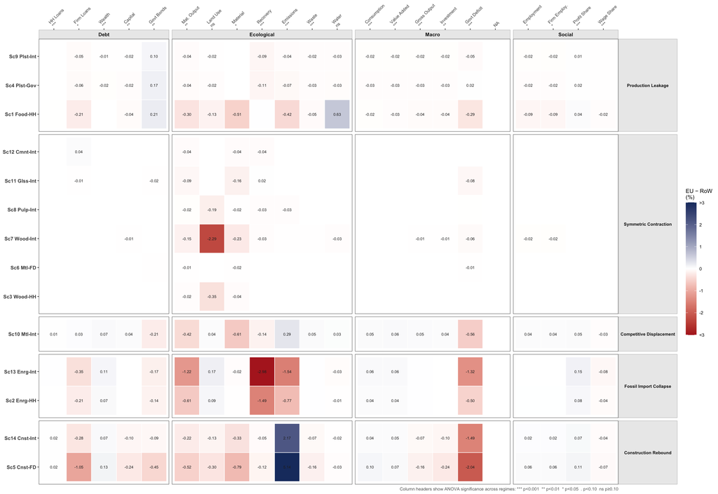

EU−RoW long-term divergence (Z1 − Z2, % deviation from baseline). Blue = EU effect exceeds RoW; red = RoW effect exceeds EU. Colour scale capped at ±3% to prevent fiscal extreme values from compressing the palette. Scenarios grouped by transmission regime (rows); variable categories (columns).

**Discussion.** The heatmap reveals an immediately striking structural feature: the vast majority of cells are near-zero (white), with intense coloration concentrated in only two regime blocks — *Fossil Import Collapse* and *Construction Rebound*. This reflects the fundamental asymmetry of the scenario set: most CE interventions operate within small-scale material substitutions that generate proportional bilateral adjustments, while energy and construction transitions operate through qualitatively different channels.

**Production Leakage** (Sc1, Sc4, Sc9) shows moderate but consistent red in ecological columns, indicating that EU’s ecological gains exceed RoW’s — but less dramatically than the fossil scenarios. The leakage occurs through intermediate import channels: secondary-sector production in the EU draws more on RoW inputs, partially diffusing the ecological gain outward.

**Competitive Displacement** (Sc10) stands out uniquely in the macro columns: blue cells for consumption, value added, gross output, and employment indicate that EU *outperforms* RoW on macroeconomic outcomes. This is the only scenario where a true sign reversal occurs — EU macro variables move positively while RoW contracts — rather than both contracting at different rates. The intensity is moderate, however, making Sc10’s statistical distinctiveness from the Fossil Import Collapse group an open question addressed in Section 5.

# 4 ANOVA: Are Regime Divergences Statistically Different?

One-way ANOVA tests whether mean EU−RoW divergence differs across the 5 transmission regimes (H₀: all group means equal; df_between = 4, df_within = 9). Effect size η² = SS_between / SS_total is analogous to R². The OLS regression fits Z2 ~ Z1 across the 14 scenarios per variable, where slope > 0 indicates co-movement and slope < 0 indicates asymmetric sign reversal. Both analyses use long-term (t+20 periods) percentage deviations from baseline.

Combined ANOVA and OLS statistics for all variables, sorted by η². ANOVA: are regime group means different? OLS: do Z1 and Z2 co-move? Sig. codes: *** p<0.001, ** p<0.01, * p<0.05, . p<0.10, ns p≥0.10.

| Variable | Category | ANOVA (divergence ~ regime) F | ANOVA (divergence ~ regime) p (ANOVA) | ANOVA (divergence ~ regime) η² | OLS (Z2 ~ Z1, n=14) Slope (Z2~Z1) | OLS (Z2 ~ Z1, n=14) R² |
| --- | --- | --- | --- | --- | --- | --- |
| lh | portfolio.choices | 147.32 | 3.4e-08 | 0.985 *** | -0.17 ** | 0.443 |
| imp | balance.of.payments | 52.79 | 3.0e-06 | 0.959 *** | -0.349 *** | 0.791 |
| rex | balance.of.payments | 52.79 | 3.0e-06 | 0.959 *** | -2.267 *** | 0.791 |
| va | production | 45.77 | 5.5e-06 | 0.953 *** | -0.366 *** | 0.833 |
| fd | production | 43.89 | 6.6e-06 | 0.951 *** | -0.308 . | 0.277 |
| wb | labor.market | 25.14 | 6.7e-05 | 0.918 *** | -0.301 ** | 0.447 |
| ydw | Households | 25.14 | 6.7e-05 | 0.918 *** | -0.301 ** | 0.447 |
| t | govt.central.bank | 24.64 | 7.3e-05 | 0.916 *** | -0.299 *** | 0.977 |
| yd | Households | 24.16 | 7.9e-05 | 0.915 *** | -0.265 *** | 0.983 |
| gdef | govt.central.bank | 22.01 | 1.1e-04 | 0.907 *** | 1.258 *** | 0.978 |
| v | Households | 21.10 | 1.4e-04 | 0.904 *** | -0.191 *** | 0.917 |
| ydc | Households | 19.36 | 1.9e-04 | 0.896 *** | -0.124 *** | 0.867 |
| f_f | production | 18.08 | 2.5e-04 | 0.889 *** | -0.13 *** | 0.887 |
| rec | Ecological | 16.63 | 3.5e-04 | 0.881 *** | 0.036 *** | 0.867 |
| ineq | Households | 15.76 | 4.3e-04 | 0.875 *** | -0.02 . | 0.237 |
| shp | Households | 15.74 | 4.3e-04 | 0.875 *** | -0.021 . | 0.237 |
| shw | Households | 15.74 | 4.3e-04 | 0.875 *** | -0.021 . | 0.237 |
| c | Households | 15.09 | 5.0e-04 | 0.87 *** | -0.312 *** | 0.991 |
| go | production | 13.31 | 8.1e-04 | 0.855 *** | 0.118 * | 0.364 |
| emis | Ecological | 13.06 | 8.7e-04 | 0.853 *** | 0.008 ** | 0.466 |
| wa | Ecological | 13.03 | 8.7e-04 | 0.853 *** | 0.113 * | 0.360 |
| id | investment | 12.02 | 1.2e-03 | 0.842 ** | 0.086 ** | 0.459 |
| debt_gdp | govt.central.bank | 11.57 | 1.4e-03 | 0.837 ** | -0.307 *** | 0.934 |
| k | investment | 10.48 | 1.9e-03 | 0.823 ** | 0.087 ** | 0.487 |
| x_mat | Ecological | 9.31 | 2.9e-03 | 0.805 ** | 0.057 ** | 0.446 |
| b_s | govt.central.bank | 9.03 | 3.2e-03 | 0.801 ** | -0.287 *** | 0.936 |
| y | production | 8.62 | 3.8e-03 | 0.793 ** | 0.116 * | 0.332 |
| co2_cum | Ecological | 7.91 | 5.1e-03 | 0.778 ** | 0.009 *** | 0.639 |
| nf | labor.market | 5.65 | 1.5e-02 | 0.715 * | -0.237 ** | 0.443 |
| n | labor.market | 5.65 | 1.5e-02 | 0.715 * | -0.237 ** | 0.443 |
| lf | investment | 5.19 | 1.9e-02 | 0.698 * | 0.034 *** | 0.814 |
| mat | Ecological | 4.04 | 3.8e-02 | 0.642 * | 0.099 ** | 0.505 |
| water | Ecological | 0.74 | 5.9e-01 | 0.248 ns | 0.077 *** | 0.784 |
| land | Ecological | 0.42 | 7.9e-01 | 0.158 ns | 0.003 ns | 0.034 |

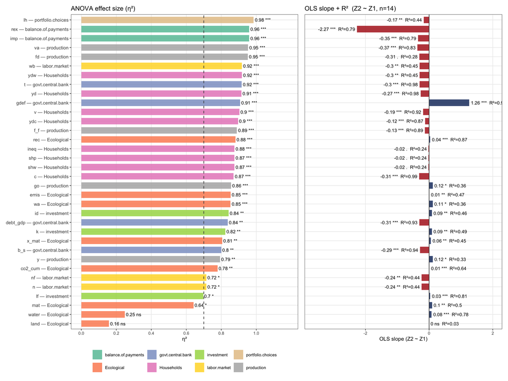

Left panel: η² (ANOVA effect size) per variable, coloured by category. Right panel: OLS slope (Z2 ~ Z1) with R² label. Both sorted by η². Dashed lines at η²=0.70 and slope=0. Stars = significance level.

# 5 Hierarchical Clustering: Two Coordinate Spaces

## 5.1 Why the coordinate space matters

The five transmission regimes are defined by a *pair* of regional signs. “Competitive Displacement” is the case where the EU expands **while** the Rest of World contracts; “Symmetric Contraction” is the case where both move the same way. Those are statements about the joint pattern of `Z1` and `Z2`, not about their difference.

This has a direct consequence for how the scenarios may be clustered. A divergence of +0.5 is produced equally by (`Z1` +0.4, `Z2` −0.1) — a genuine sign reversal — and by (`Z1` +0.6, `Z2` +0.1), where both regions expand. Those are two different regimes with identical coordinates. **Differencing removes the information the regime taxonomy is defined by**, and no clustering algorithm can recover a distinction the coordinate transform has already destroyed.

Two spaces are therefore used throughout what follows, and they answer different questions:

| space | vector per scenario | what it can test |
| --- | --- | --- |
| **Divergence** `Z1 − Z2` | one value per variable | cross-border *asymmetry* — how unequally a shock lands |
| **Joint** `(Z1, Z2)` | two values per variable, standardised separately | the full two-region *signature*, including sign patterns |

The divergence space additionally destroys the current account and trade balance outright: `cab` and `tb` are bilateral accounting identities that cancel exactly between the regions, so their divergence is identically zero and they are dropped. In the joint space both survive.

## 5.2 Clustering Procedure

**Algorithm:** Ward’s D2 linkage with Euclidean distance. Ward’s method minimises within-cluster total variance at each merge step, producing compact, similarly-sized clusters appropriate for the small sample (n=14).

## 5.3 Dendrogram

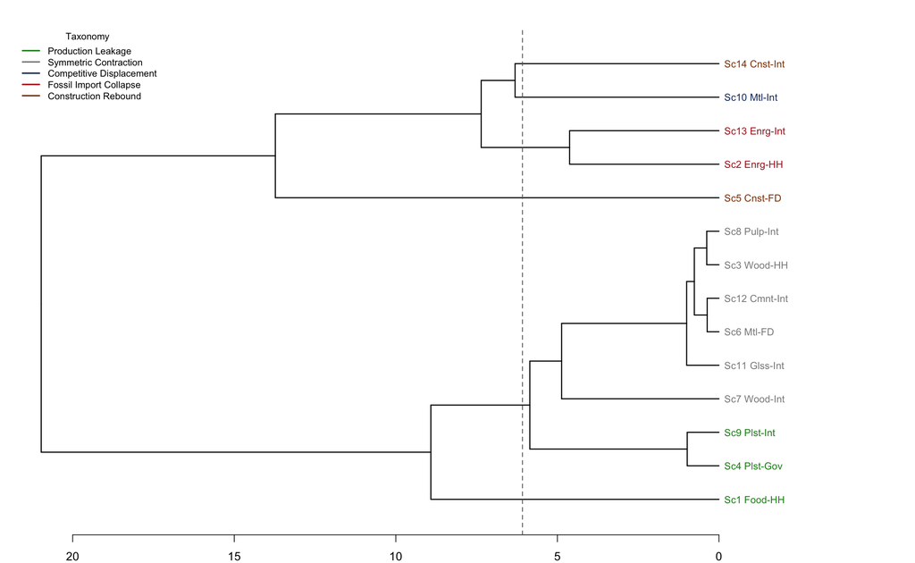

## 5.4 How Many Clusters? Silhouette Against a Permutation Null

Three of the four criteria previously reported here — the gap statistic and the AIC and BIC of a Gaussian mixture model — are not usable on this data, and the reason is structural rather than incidental. With 34 variables and 14 scenarios, p/n ≈ 2.4.

- The **gap statistic** compares observed within-cluster dispersion against a uniform reference distribution over the bounding box of the data. In 34 dimensions containing 14 points that reference is dispersed almost everywhere, the comparison degenerates, and the 1-SE rule fires at the first k it tests.
- **Gaussian mixture models** estimate a mean vector and a covariance structure per component. With p > n the likelihood is not identified, and the reported optimum is the search ceiling rather than an estimate.

They are replaced here by a **permutation null**, which makes no distributional assumption: each variable’s column is permuted independently, destroying the association between variables within a scenario while preserving every variable’s marginal distribution exactly. The question it answers is the one that matters — is the observed cluster separation greater than what exchangeable data of the same shape produces?

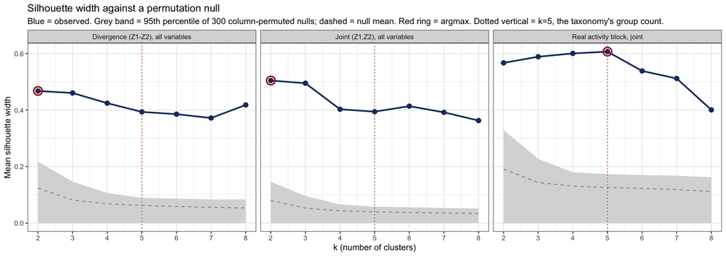

**Discussion.** Two results, and they must be kept apart.

**There is cluster structure, and it is unambiguous.** Across 300 permutations the observed silhouette is never matched at any k from 2 to 8, in any of the three variable sets — not one of the 300 draws matched it, so the permutation p-value is below the resolution of the test, 0.0033 (0 exceedances out of 300) — with observed values 3.0 to 11.0 times the null mean. The earlier reading — that a gap statistic and a BIC of k=1 indicated no structure — was wrong: those criteria are uninformative here, not negative.

**The number of clusters is not identified.** On the pooled variable set silhouette is effectively flat between k=2 and k=3 (a gap of 0.009 in the joint space) and declines gently thereafter without a clear interior maximum. That is the expected behaviour of a relative criterion at n=14 and it is not a defect in the scenario set.

The consequence for this analysis is methodological. Because k is not identified, the five-regime taxonomy cannot be *discovered* from these data. It can, however, be **tested**: it is a partition specified in advance on mechanistic grounds, and the question is whether clustering recovers it. That question is answered with the adjusted Rand index (ARI), which counts the scenario pairs two partitions agree about, corrected for chance — 0 is chance-level agreement, 1 is identity.

## 5.5 Which Variables Carry the Regime Signal?

The regimes are named for transmission mechanisms — Production *Leakage*, Competitive *Displacement*, Fossil *Import Collapse*, Symmetric *Contraction*, Construction *Rebound*. None names an ecological outcome. If that naming is more than rhetorical, the regime signal should sit in the variables through which transmission runs, and not in the ecological satellite accounts.

That is testable. Each of the six blocks defined above is clustered on its own, in both spaces, and its partition at the taxonomy’s own k (5) scored against the taxonomy.

Silhouette schedule by variable block and coordinate space. Final column: adjusted Rand index of that block's k=5 partition against the taxonomy under test.

| Space | Block | p | best k | silhouette, k = 2 .. 8 | ARI @ k=5 |
| --- | --- | --- | --- | --- | --- |
| Divergence | Real activity | 6 | 2 | 0.602 0.545 0.536 0.592 0.534 0.495 0.411 | 0.906 |
| Divergence | Finance & wealth | 5 | 3 | 0.573 0.598 0.557 0.483 0.464 0.418 0.397 | 0.906 |
| Divergence | Fiscal | 4 | 4 | 0.618 0.599 0.640 0.636 0.569 0.475 0.416 | 0.872 |
| Divergence | External | 2 | 2 | 0.717 0.677 0.701 0.701 0.658 0.587 0.449 | 0.843 |
| Divergence | All variables | 34 | 2 | 0.468 0.460 0.424 0.394 0.385 0.372 0.418 | 0.565 |
| Divergence | Labour & distribution | 9 | 2 | 0.561 0.531 0.465 0.462 0.539 0.507 0.450 | 0.492 |
| Divergence | Ecological | 8 | 2 | 0.515 0.407 0.432 0.445 0.409 0.425 0.390 | 0.190 |
| Joint | All variables | 72 | 2 | 0.504 0.495 0.403 0.394 0.414 0.392 0.363 | 0.936 |
| Joint | Real activity | 12 | 5 | 0.567 0.589 0.600 0.607 0.538 0.512 0.401 | 0.906 |
| Joint | Fiscal | 8 | 4 | 0.638 0.629 0.708 0.665 0.586 0.513 0.453 | 0.872 |
| Joint | External | 8 | 2 | 0.676 0.577 0.590 0.617 0.588 0.518 0.411 | 0.872 |
| Joint | Finance & wealth | 10 | 3 | 0.599 0.612 0.557 0.495 0.498 0.451 0.406 | 0.843 |
| Joint | Labour & distribution | 18 | 2 | 0.514 0.477 0.447 0.434 0.496 0.481 0.443 | 0.492 |
| Joint | Ecological | 16 | 2 | 0.506 0.384 0.378 0.407 0.342 0.358 0.316 | 0.435 |

**Discussion.** The blocks differ enormously in what they carry, and the pattern is systematic.

**Real activity in the joint space is the only specification whose silhouette selects k=5** (0.607, rising monotonically from k=2), and its partition matches the taxonomy at ARI 0.906.

**The External block is the sharpest small block.** In the divergence space it retains only two usable variables — `imp` and `rex`, once `cab` and `tb` have cancelled — and still reaches the highest silhouette in the table (0.717) with ARI 0.843. In the joint space all four survive and ARI rises to 0.872. Cross-border trade flows discriminate the regimes nearly as well as real activity does, on a fraction of the variables.

**The Ecological block carries almost no regime information**: ARI 0.190 in the divergence space and 0.435 in the joint space, the two lowest figures in the table. This is the substantive finding of the section, not a nuisance result. Transmission regimes are constituted in the trade and real-activity structure; **ecological outcomes are consequences of those regimes rather than definitions of them**. The regime taxonomy and the ecological results are therefore logically independent, which is what allows the paper to report an ecological trilemma *within* a regime rather than confounding the two.

## 5.6 Does the Data Recover the Five-Regime Taxonomy?

Adjusted Rand index between the data partition and the taxonomy of 5 groups, by k and coordinate space, on the full variable set of 14 scenarios.

| Space | k=2 | k=3 | k=4 | k=5 | k=6 |
| --- | --- | --- | --- | --- | --- |
| Divergence | 0.432 | 0.449 | 0.488 | 0.565 | 0.586 |
| Joint | 0.432 | 0.449 | 0.821 | 0.936 | 0.867 |

On the full variable set in the joint space, the k=5 partition matches the taxonomy at **ARI 0.936**. In the divergence space the same cut reaches only 0.565.

That partition is **stable**: removing each of the 72 columns in turn and re-clustering gives an adjusted Rand index of 1.000 against the full-set partition in 72 of 72 cases. Bootstrap resampling of the variable set (500 replicates, columns drawn with replacement) gives mean ARI 0.836, with 67% of replicates at or above 0.8.

**Two of the 5 regimes are recovered exactly by almost every specification.** Production Leakage {Sc1, Sc4, Sc9} and Symmetric Contraction {Sc3, Sc6, Sc7, Sc8, Sc11, Sc12} — 9 of the 14 scenarios — appear with no errors in 9 of the 9 block-and-space combinations scoring at or above ARI 0.8. They are the solid core of the taxonomy.

**The disagreements are confined to the five high-leverage scenarios and are systematic, not random.** Sc5 (Cnst-FD) is a singleton in every high-ARI partition: it is an outlier in magnitude rather than a regime member. Sc10 (Mtl-Int) never forms its own cluster, attaching to {Sc2, Sc13} in the real-activity and finance blocks and to {Sc14} in the full joint set. Sc14 (Cnst-Int) moves between blocks. These three facts are reported as findings rather than smoothed away; the implications for “Competitive Displacement” as a standalone regime are taken up below.

**A caution on variable selection.** Drawing random subsets of the pooled divergence variables, silhouette lands on k=5 in roughly one draw in ten and the k=5 partition reaches ARI ≥ 0.9 in about one in four. Searching over subsets until one yields five clusters is therefore *not* evidence. Two things distinguish the results above from that failure: the six blocks are a pre-existing economic partition of the variables rather than a search, and the reason for expecting real activity and external flows to carry the signal is stated independently of the result. The mean ARI of 0.62–0.66 across *random* subsets separately shows the taxonomy is legible in almost any slice of these data, so it does not rest on one fortunate specification.

## 5.7 Cluster Assignments Across k

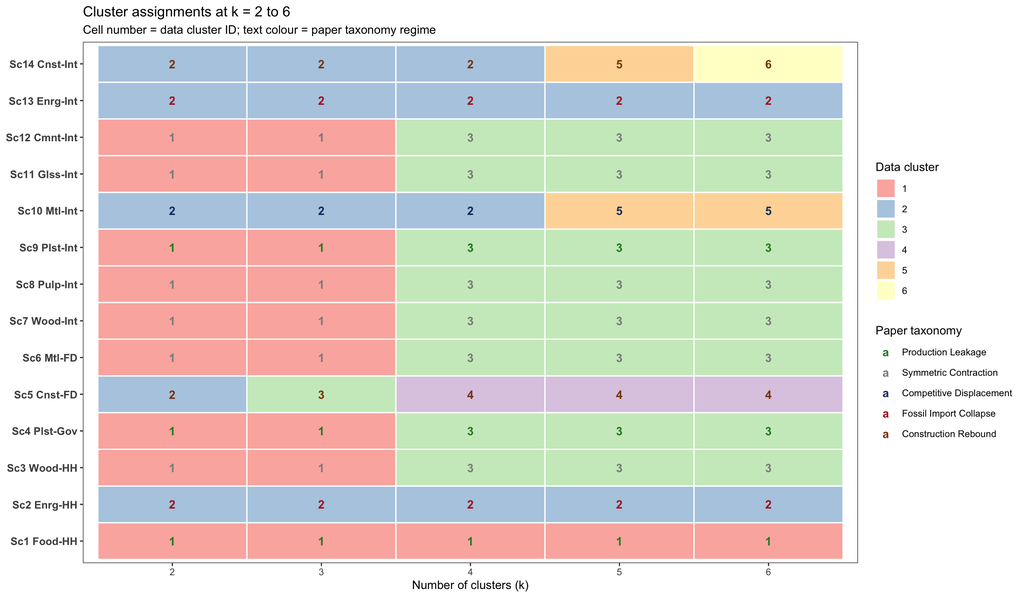

Cluster membership for each scenario at k=2 through k=6. Label colour = paper taxonomy. The stable core groupings are immediately visible: Production Leakage + Symmetric Contraction (left) remain together at k=2,3; the largest outlier separates first; the high-leverage group gradually dissolves at higher k.

**Discussion.** This panel is the most direct comparison between the data-driven structure and the paper taxonomy. Several features stand out:

**Sc5 (Cnst-FD) separates first** at k=3, confirming it as the strongest outlier in the dataset. No matter how many clusters are requested, Sc5 occupies its own group from k=3 onwards. The construction final-demand rebound is not just a different *type* of transmission — it is a different *order of magnitude*.

## 5.8 Silhouette Plots by k

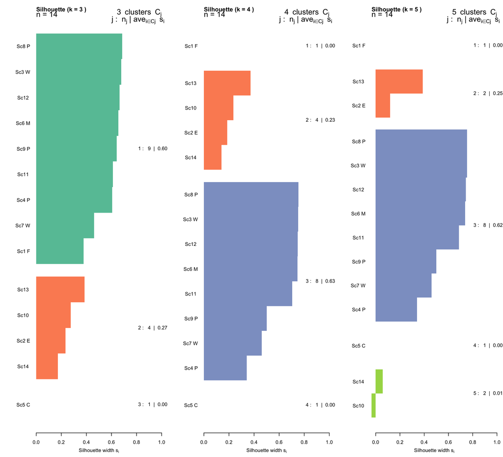

Individual silhouette plots at k=3, 4, and 5. Each bar represents one scenario; bar length = silhouette coefficient (how well the scenario fits its cluster vs the next-best cluster). Negative values indicate potential misclassification.

**Discussion.** Silhouette plots reveal which specific scenarios are most and least confidently classified at each k. Average silhouette width is 0.460 at k=3, 0.424 at k=4 and 0.394 at k=5.

At **k=4**, two scenarios are singletons and so score 0 by definition: Sc1 (Food-HH), which has the largest household channel and is the furthest of the leakage trio from the other two, and Sc5. The Sc10/Sc2/Sc13/Sc14 group stays whole at this k.

At **k=5**, Sc10’s coefficient turns negative (−0.03), the only negative value in the schedule: cut into {Sc10, Sc14}, it sits closer to another cluster than to its own. That is the sharpest single expression of Sc10’s weak standing on this registry, and it is examined in “On ‘Competitive Displacement’ as a Standalone Regime” below.

# 6 Taxonomy Comparison: Paper vs. Data

Comparison of the paper taxonomy (5 regimes) with data-driven cluster assignments at k=3 and k=5.

| Scenario | Paper regime | Data k=3 | Data k=5 |
| --- | --- | --- | --- |
| Sc1 Food-HH | Production Leakage | 1 | 1 |
| Sc2 Enrg-HH | Fossil Import Collapse | 2 | 2 |
| Sc3 Wood-HH | Symmetric Contraction | 1 | 3 |
| Sc4 Plst-Gov | Production Leakage | 1 | 3 |
| Sc5 Cnst-FD | Construction Rebound | 3 | 4 |
| Sc6 Mtl-FD | Symmetric Contraction | 1 | 3 |
| Sc7 Wood-Int | Symmetric Contraction | 1 | 3 |
| Sc8 Pulp-Int | Symmetric Contraction | 1 | 3 |
| Sc9 Plst-Int | Production Leakage | 1 | 3 |
| Sc10 Mtl-Int | Competitive Displacement | 2 | 5 |
| Sc11 Glss-Int | Symmetric Contraction | 1 | 3 |
| Sc12 Cmnt-Int | Symmetric Contraction | 1 | 3 |
| Sc13 Enrg-Int | Fossil Import Collapse | 2 | 2 |
| Sc14 Cnst-Int | Construction Rebound | 2 | 5 |

# 7 Discussion of Main Findings

## 7.1 What the Divergence Space Groups, and What It Cannot

The section below describes the structure the *divergence* clustering finds. It is a real structure, but it must be read for what it is: a grouping by cross-border **asymmetry**, not by regime. Three groups appear at k=3 in that space, and they are not the five regimes — they cannot be, because differencing has removed the two-region sign patterns the regimes are defined by (see “Why the coordinate space matters”). The recovery of the taxonomy is reported in “Does the Data Recover the Five-Regime Taxonomy?” above, on the joint profile, at ARI 0.936.

**Cluster A — Near-zero bilateral divergence** (Sc3, Sc6–Sc9, Sc11–Sc12, plus Sc1/Sc4 at k=3): These scenarios generate proportional bilateral adjustments. The EU restructuring is too small in absolute scale to generate measurable directional asymmetry in any variable category. The paper’s distinction between “Symmetric Contraction” and “Production Leakage” within this cluster is theoretically motivated — the sign of the divergence differs (Production Leakage generates slightly negative divergences, meaning RoW benefits marginally more than EU) — but statistically the difference is within the noise. At k=3 the data confirms this: both regimes occupy the same cluster.

One caveat on Sc5’s isolation. Sc5 is run at ρ = 0.05 where the other scenarios use ρ = 0.2, so part of the distance separating it from everything else is a shock-magnitude choice rather than a structural difference in transmission. Its singleton status is robust across every specification tried, but the analysis here cannot separate the two contributions; a re-run at common ρ would settle it.

## 7.2 On “Competitive Displacement” as a Standalone Regime

The original justification for isolating Sc10 (Mtl-Int) as “Competitive Displacement” rests on a mechanistic distinction: it is the *only* scenario in the set where EU macro variables move *positive* while RoW macro variables move *negative* simultaneously (true sign reversal). In all other high-divergence scenarios, both regions move in the same direction — EU contracts less than RoW, but both contract.

## 7.3 Why Energy and Construction Dominate

Two structural features of the model explain the extreme salient of the energy (Sc13) and construction (Sc5) scenarios:

**Energy (Sc13):** The intermediate energy channel is simultaneously the *largest* channel in the scenario set (14.8 billion EUR) and the *most intensity-differential* material pair (emission intensity ratio 3.3:1 between secondary and primary energy). These two factors — scale and intensity differential — are multiplicative in the ΔM formula, making Sc13 the highest-leverage ecological scenario by construction. The cross-border fiscal effect is equally extreme because EU fossil fuel imports represent a direct bilateral income transfer: reducing them by ρ=0.2 removes a substantial, concentrated revenue stream from RoW hydrocarbon exporters without any compensating income source within the model’s RoW structure.

**Construction (Sc5):** The construction channel uniquely operates through *investment*, not consumption or intermediate demand. The investment multiplier is structurally larger than consumption or intermediate multipliers because investment triggers capital formation, which activates the full capital-investment loop in the SFC model. At ρ=0.05 (lower than the standard ρ=0.2 used for other scenarios), construction still generates the largest absolute divergences because the investment base (88.7 billion EUR, 66.7% of total construction demand) is the largest single channel in the scenario set. The ecological rebound (+5.14 in emissions) occurs because renovation and refurbishment are more energy-intensive per unit of output than new construction in the current A-matrix — the CE intervention increases construction activity, which raises upstream fossil energy demand domestically even as it reduces material throughput per unit. EU land use in Sc5 in fact *falls* (−0.33% against baseline), so the rebound is atmospheric, not land-based.